# Level of CO2 Emission on Agricultural Production

Justin Chow and Max Payen

2023-03-15

## Descriptive Statistics

```
Descriptive Statistics
===================================================
Statistic    N   Mean  Median St. Dev.  Min   Max
---------------------------------------------------
co2_emission 60  5.18   4.27    3.94   0.69  15.43
land_area    60 40.43  42.36   17.94   2.70  80.72
food_index   60 104.04 102.03   8.69   81.38 136.05
crop_index   60 102.65 103.41  10.29   68.34 123.84
---------------------------------------------------
```

## Exploratory Data Analysis

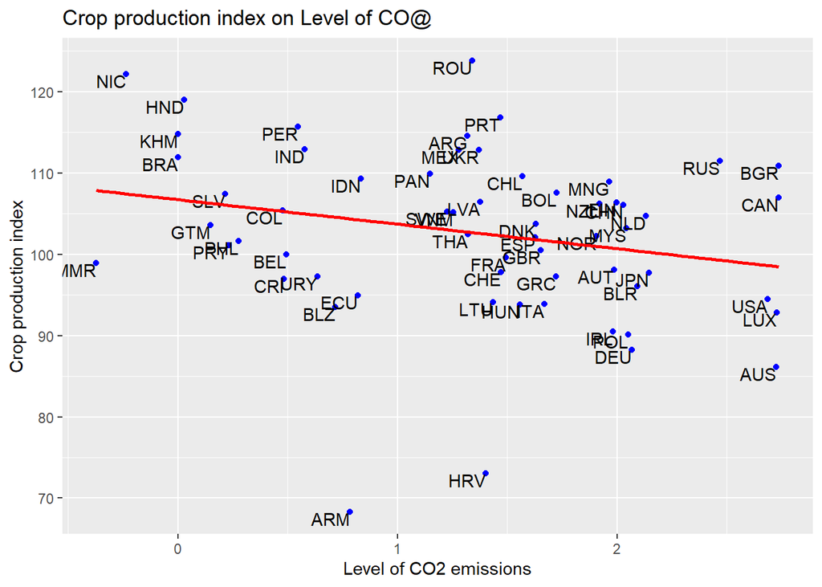

### Is there a relationship between level of CO2 emissions and the crop production index for all 60 countries?

There seems to be a negative relationship between level of CO2 emissions and the crop production index of all 60 countries. There are European country outliers such as Croatia (HRV) and Armenia (ARM) that have much smaller crop production index compared to the rest of the countries, but other than that it resembles a linear relationship with the average level of CO2 emission located where crop production index is 100.

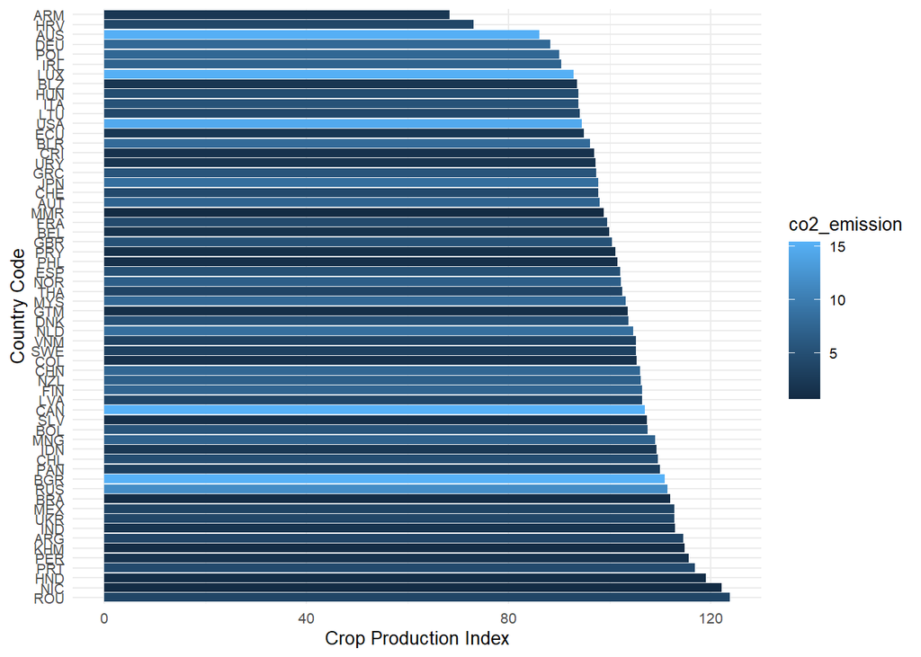